# Loading & Summarizing Data

August 30, 2018

## Purpose of Shiny App

The purpose of this shiny app is to facilitate the process of loading and summarizing data. Frequently, it takes time and effort to load data into R and more often than not, the code being used is exactly the same - the only difference being the name of the dataset. This shiny app provides a quick user interface to examine the dataset in question via the following interactive panels.

### **Sidebar Panel**

The side panel allows the user to load the desired dataset and tweak a few parameters so that the dataset is loaded properly and the desired plots are generated.

### **Tabs**

1. Instructions - detailed step-by-step instructions on how to use the shiny app
2. Table - displays the dataset in table form
3. Summary - prints out the mean, median, and quartile information for all variables in the dataset
4. Plots - plots different figures to show distribution of data and how variables interact with each other

## Screenshots

Below is a screenshot of the shiny app with a brief description of the interactive areas:

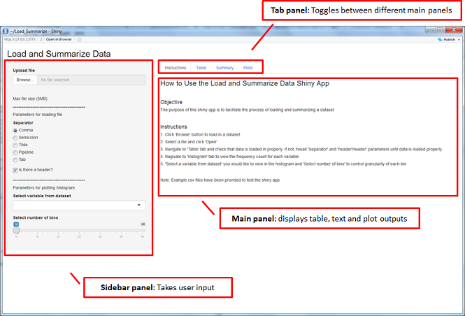

## Appendix 1 - Histogram

Below is the code used to generate the plots in the shiny app:

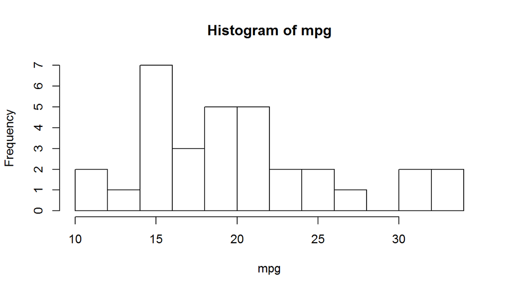

```r
hist(mtcars$mpg, breaks = 10, main = paste("Histogram of mpg"), xlab = "mpg")
```

## Appendix 2 - Pairs Plot

Below is the code used to generate the plots in the shiny app:

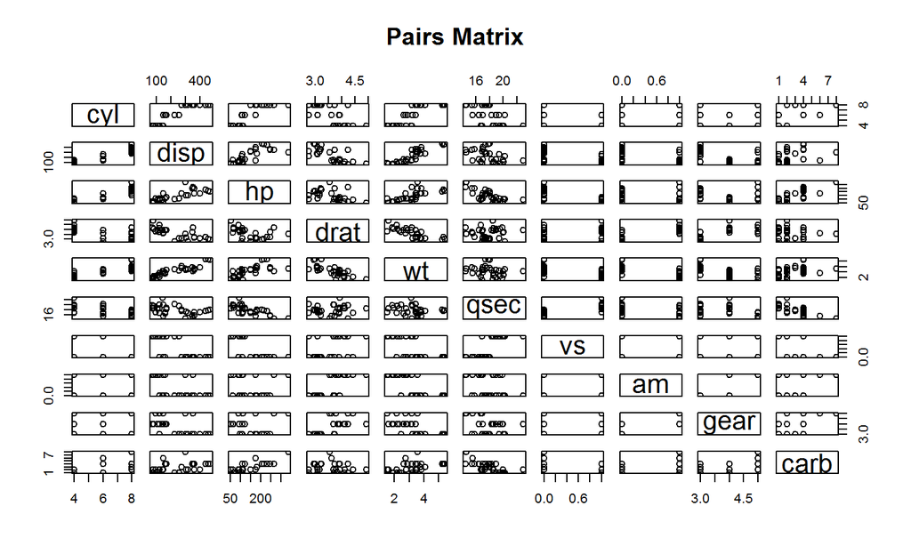

```r
pairs(~., data=mtcars[,-1], main="Pairs Matrix")
```